# hw5_Weida

Chase Weida; Github: cweida

4/10/2020

### 1. Importing Data

```r
df <- readr::read_csv(file = './Data/2019_Iowa_Liquor_Sales.csv')
str(df)
```

```
## Classes 'spec_tbl_df', 'tbl_df', 'tbl' and 'data.frame': 63103 obs. of  24 variables:
##  $ Invoice/Item Number  : chr  "INV-16712000040" "INV-16712000012" "INV-16712000070" "INV-16712000009" ...
##  $ Date                 : chr  "01/03/2019" "01/03/2019" "01/03/2019" "01/03/2019" ...
##  $ Store Number         : num  2500 2500 2500 2500 2500 ...
##  $ Store Name           : chr  "Hy-Vee Food Store #1 / Ames" "Hy-Vee Food Store #1 / Ames" "Hy-Vee Food Store #1 / Ames" "Hy-Vee Food Store #1 / Ames" ...
##  $ Address              : chr  "3800 W Lincoln Way" "3800 W Lincoln Way" "3800 W Lincoln Way" "3800 W Lincoln Way" ...
##  $ City                 : chr  "Ames" "Ames" "Ames" "Ames" ...
##  $ Zip Code             : num  50010 50010 50010 50010 50010 ...
##  $ Store Location       : chr  NA NA NA NA ...
##  $ County Number        : num  85 85 85 85 85 85 85 85 85 85 ...
##  $ County               : chr  "STORY" "STORY" "STORY" "STORY" ...
##  $ Category             : num  1042100 1012100 1031100 1012100 1081400 ...
##  $ Category Name        : chr  "Imported Dry Gins" "Canadian Whiskies" "American Vodkas" "Canadian Whiskies" ...
##  $ Vendor Number        : chr  "260" "260" "055" "260" ...
##  $ Vendor Name          : chr  "DIAGEO AMERICAS" "DIAGEO AMERICAS" "SAZERAC NORTH AMERICA" "DIAGEO AMERICAS" ...
##  $ Item Number          : num  28867 11294 37936 10805 82867 ...
##  $ Item Description     : chr  "Tanqueray Gin" "Crown Royal" "Skol Vodka" "Crown Royal Regal Apple" ...
##  $ Pack                 : num  12 24 12 24 12 12 6 6 12 12 ...
##  $ Bottle Volume (ml)   : num  1000 375 750 375 1000 750 1750 1750 750 375 ...
##  $ State Bottle Cost    : num  15.5 8 3.64 8 7.87 ...
##  $ State Bottle Retail  : num  23.25 12 5.46 12 11.81 ...
##  $ Bottles Sold         : num  12 4 12 4 12 3 6 12 2 4 ...
##  $ Sale (Dollars)       : num  279 48 65.5 48 141.7 ...
##  $ Volume Sold (Liters) : num  12 1.5 9 1.5 12 2.25 10.5 21 1.5 1.5 ...
##  $ Volume Sold (Gallons): num  3.17 0.39 2.37 0.39 3.17 0.59 2.77 5.54 0.39 0.39 ...
##  - attr(*, "spec")=
##   .. cols(
##   ..   `Invoice/Item Number` = col_character(),
##   ..   Date = col_character(),
##   ..   `Store Number` = col_double(),
##   ..   `Store Name` = col_character(),
##   ..   Address = col_character(),
##   ..   City = col_character(),
##   ..   `Zip Code` = col_double(),
##   ..   `Store Location` = col_character(),
##   ..   `County Number` = col_double(),
##   ..   County = col_character(),
##   ..   Category = col_double(),
##   ..   `Category Name` = col_character(),
##   ..   `Vendor Number` = col_character(),
##   ..   `Vendor Name` = col_character(),
##   ..   `Item Number` = col_double(),
##   ..   `Item Description` = col_character(),
##   ..   Pack = col_double(),
##   ..   `Bottle Volume (ml)` = col_double(),
##   ..   `State Bottle Cost` = col_double(),
##   ..   `State Bottle Retail` = col_double(),
##   ..   `Bottles Sold` = col_double(),
##   ..   `Sale (Dollars)` = col_double(),
##   ..   `Volume Sold (Liters)` = col_double(),
##   ..   `Volume Sold (Gallons)` = col_double()
##   .. )
```

### 2. Data Cleaning

#### a. Extracting Latitude and Longitude

```r
df <- df %>% filter(is.na(`Store Location`) == FALSE) %>%
  mutate(LatLong = substr(`Store Location`, 8, nchar(`Store Location`)-1)) %>%
  separate(LatLong, c('Longitude','Latitude'), sep = " " ) %>%
  select(-`Store Location`)
```

#### b. Separate Day/Month/Year

```r
df <- df %>% separate(Date, c("Month", "Day", "Year"), sep = "/") %>% transform()
```

#### c. Ensure proper data types

```r
df[, c("Latitude", "Longitude", "Day", "Month", "Year", "Vendor Number")] <- sapply(df[, c("Latitude", "Longitude", "Day", "Month", "Year", "Vendor Number")], as.numeric)
str(df)
```

```
## Classes 'tbl_df', 'tbl' and 'data.frame':    48250 obs. of  27 variables:
##  $ Invoice/Item Number  : chr  "INV-16835000019" "INV-16886300007" "INV-17377700173" "INV-17376600028" ...
##  $ Month                : num  1 1 2 2 2 2 2 2 2 2 ...
##  $ Day                  : num  9 11 6 6 6 13 13 13 13 27 ...
##  $ Year                 : num  2019 2019 2019 2019 2019 ...
##  $ Store Number         : num  4509 5187 4129 3973 2501 ...
##  $ Store Name           : chr  "AJ'S LIQUOR II" "Kwik Stop Liquor & Groceries Ames" "Cyclone Liquors" "MMDG SPIRITS / Ames" ...
##  $ Address              : chr  "2515 Chamberlain" "125 6th ST" "626 Lincoln Way" "126A Welch Ave" ...
##  $ City                 : chr  "Ames" "Ames" "Ames" "Ames" ...
##  $ Zip Code             : num  50010 50010 50010 50014 50010 ...
##  $ County Number        : num  85 85 85 85 85 85 85 85 85 85 ...
##  $ County               : chr  "STORY" "STORY" "STORY" "STORY" ...
##  $ Category             : num  1031200 1032100 1081400 1081300 1081200 ...
##  $ Category Name        : chr  "American Flavored Vodka" "Imported Vodkas" "American Schnapps" "American Cordials & Liqueur" ...
##  $ Vendor Number        : num  259 35 65 434 216 420 115 434 434 461 ...
##  $ Vendor Name          : chr  "Heaven Hill Brands" "BACARDI USA INC" "Jim Beam Brands" "LUXCO INC" ...
##  $ Item Number          : num  36606 34359 82787 76487 80447 ...
##  $ Item Description     : chr  "Deep Eddy Orange" "Grey Goose" "Dekuyper Buttershots" "Paramount Amaretto" ...
##  $ Pack                 : num  12 12 12 12 6 24 6 12 6 12 ...
##  $ Bottle Volume (ml)   : num  750 200 1000 1000 750 200 1750 750 1750 750 ...
##  $ State Bottle Cost    : num  9 5 7.87 4.05 10 6.24 13 5.48 7.17 9.01 ...
##  $ State Bottle Retail  : num  13.5 7.5 11.81 6.08 15 ...
##  $ Bottles Sold         : num  2 12 1 7 6 3 6 2 6 12 ...
##  $ Sale (Dollars)       : num  27 90 11.8 42.6 90 ...
##  $ Volume Sold (Liters) : num  1.5 2.4 1 7 4.5 0.6 10.5 1.5 10.5 9 ...
##  $ Volume Sold (Gallons): num  0.39 0.63 0.26 1.84 1.18 0.15 2.77 0.39 2.77 2.37 ...
##  $ Longitude            : num  -93.7 -93.6 -93.6 -93.7 -93.6 ...
##  $ Latitude             : num  42 42 42 42 42 ...
```

### 3. Overview

#### a. Scatterplot of Lat/Long

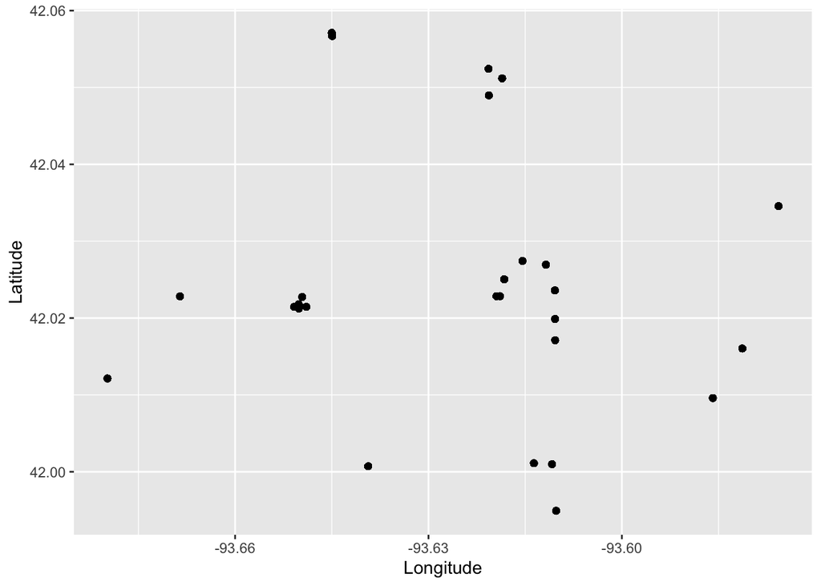

```r
ggplot(df, mapping = aes(x = Longitude, y = Latitude)) + geom_point()
```

#### b. Breakdown of liquor categories

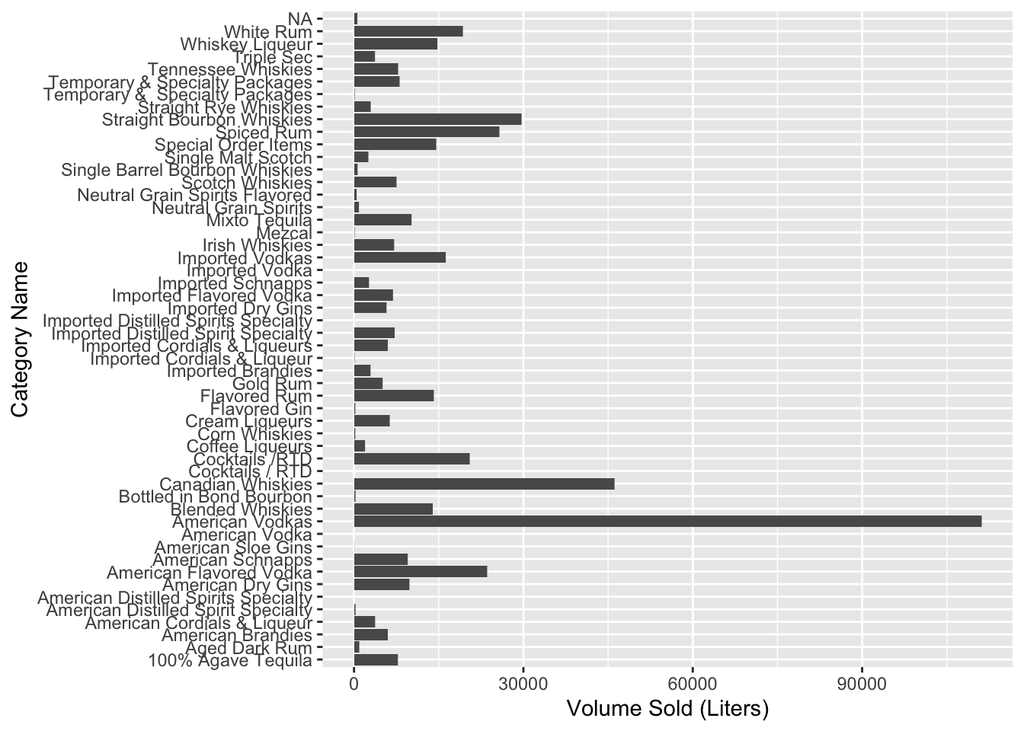

```r
df %>% ggplot(mapping = aes(x = `Category Name`, y = `Volume Sold (Liters)`)) + geom_bar(stat = 'identity') + coord_flip()
```

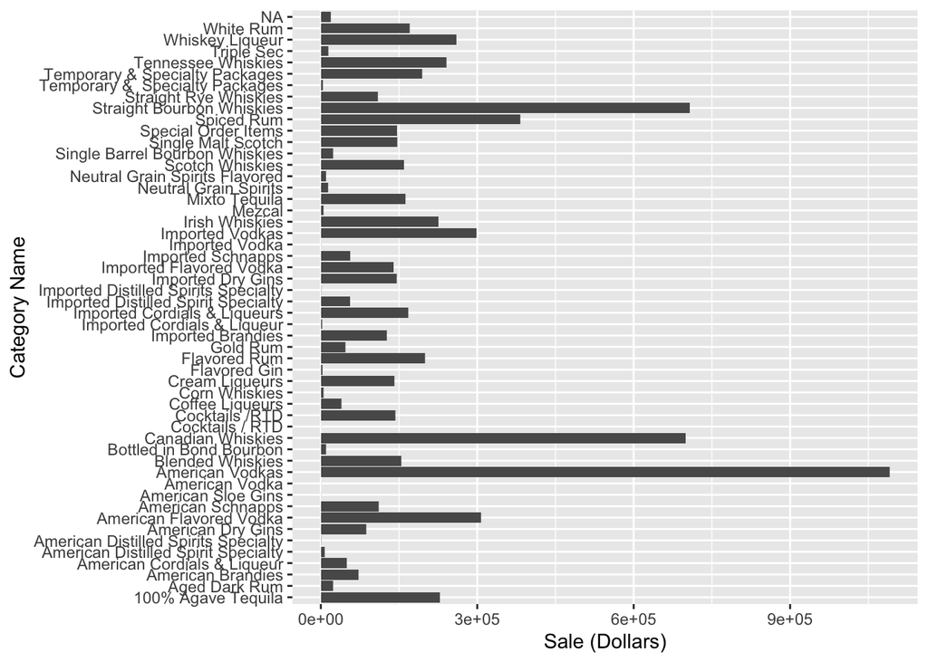

```r
df %>% ggplot(mapping = aes(x = `Category Name`, y = `Sale (Dollars)`)) + geom_bar(stat = 'identity') + coord_flip()
```

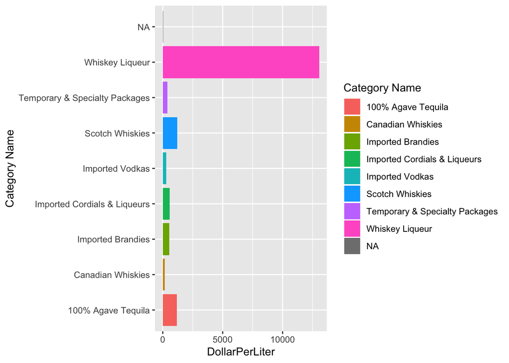

```r
df %>% group_by(`Category Name`) %>% mutate(DollarPerLiter = `Sale (Dollars)` / (`Volume Sold (Liters)`*10)) %>% filter(DollarPerLiter >= 50) %>%
  ggplot(mapping = aes(x = `Category Name`, y = DollarPerLiter, fill = `Category Name`)) +
  geom_bar(stat = 'identity') + coord_flip()
```

As seen above, there is a strong preference for American Vodkas in Ames. It dominates in both sales and volume sold. However, between the sales in dollars and sales in volume graphs we see that the ranking of certain types of alcohols changes. Notably, Whiskey Liqeur has the highest price per liter. Thus, there is a large discrepancy between volume sold and total sales in dollars.

### 4. Find daily liquor sales

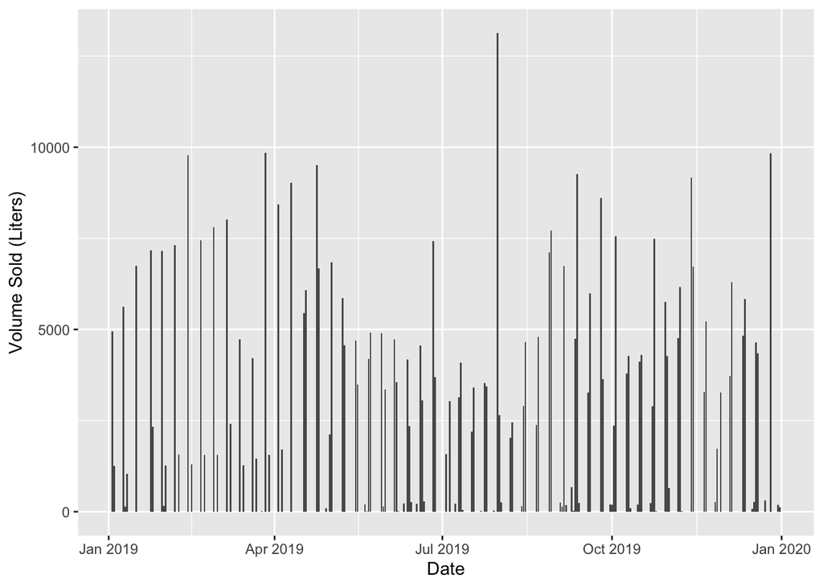

```r
df <- df %>% mutate(Date = as.Date(with(df,paste(Year,Day,Month, sep = '-')), "%Y-%d-%m"))

df %>% ggplot(mapping = aes(x = Date, y = `Volume Sold (Liters)`)) + geom_bar(stat = "identity")
```

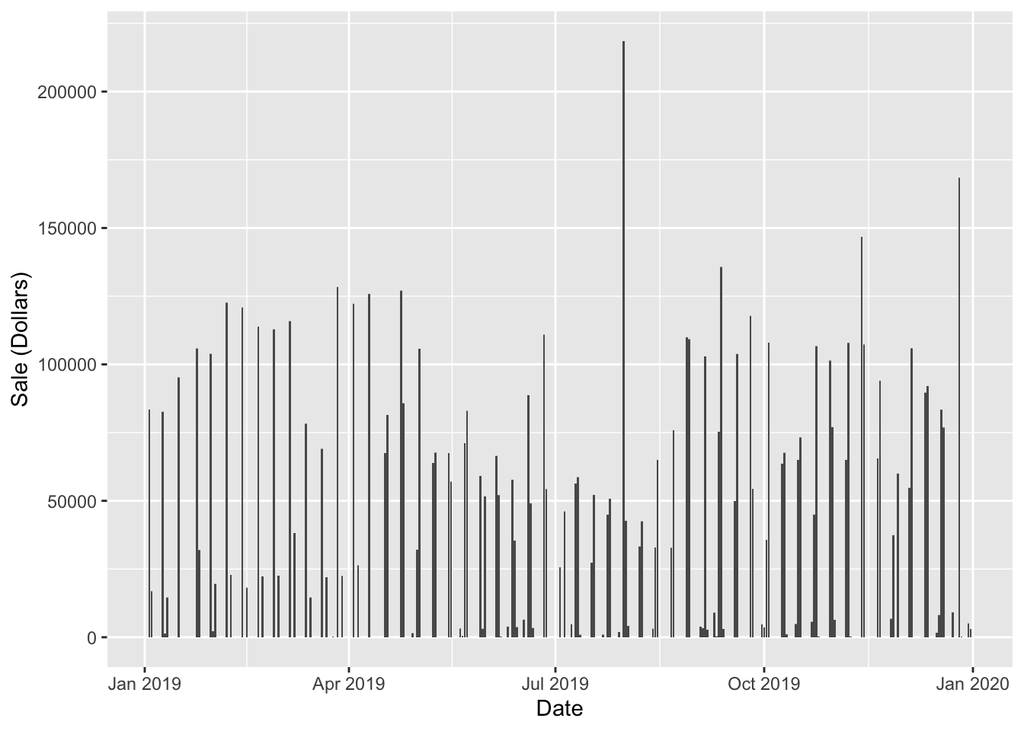

```r
df %>% ggplot(mapping = aes(x = Date, y = `Sale (Dollars)`)) + geom_bar(stat = "identity")
```

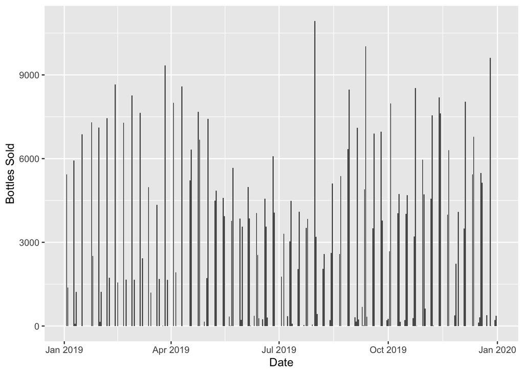

```r
df %>% ggplot(mapping = aes(x = Date, y = `Bottles Sold`)) + geom_bar(stat = "identity")
```

### 5. Plot volume sold by day

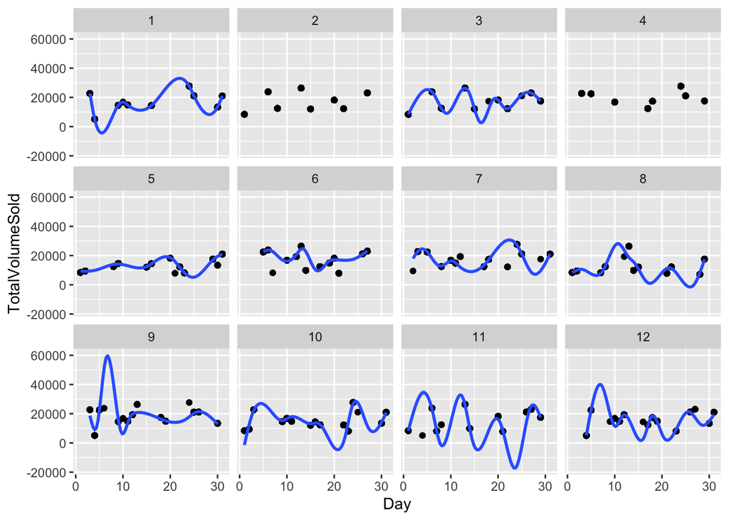

```r
df %>% group_by(Day) %>% mutate(TotalVolumeSold = sum(`Volume Sold (Liters)`)) %>% ggplot(mapping = aes(x = Day, y = TotalVolumeSold)) + geom_point() + geom_smooth() + facet_wrap(facets = df$Month)
```

### 6. Iowa State home games trend

Home game dates: AUG 31, SEP 14, SEP 21, OCT 5, OCT 26, NOV 16, and NOV 23

As seen in the graphs above, there is a slight increase in liquor sales the day before home games in Ames. Unfortunately, there seem to be days missing from the dataset which result in missing information which sometimes occurs around home games. This makes it difficult to be precise in determining how much more alcohol is sold before, during, and after home games, but it can be concluded that there is a slight trend towards higher liquor sales before the game.